# Entregável 1 - visão computacional

```python
%matplotlib inline
import cv2
from matplotlib import pyplot as plt
import numpy as np
import time as t
print("OpenCV Version : %s " % cv2.__version__)
```

```
OpenCV Version : 3.4.4
```

# Equalização de histograma

```python
rintin = cv2.imread("RinTinTin.jpg")
```

```python
rintin.shape
```

```
(240, 320, 3)
```

```python
rintin_gray = cv2.cvtColor(rintin, cv2.COLOR_RGB2GRAY)
```

```python
rintin_gray.shape
```

```
(240, 320)
```

[figure not shown]

```python
plt.imshow(rintin_gray, cmap="Greys_r", vmin=0, vmax=255)
```

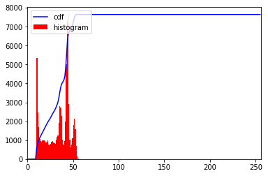

```python
hist,bins = np.histogram(rintin_gray.flatten(),256,[0,256])

cdf = hist.cumsum()
cdf_normalized = cdf * hist.max()/ cdf.max()

plt.plot(cdf_normalized, color = 'b')
plt.hist(rintin_gray.flatten(),256,[0,256], color = 'r')
plt.xlim([0,256])
plt.legend(('cdf','histogram'), loc = 'upper left')
plt.show()
```

```python
rintin_gray.min(), rintin_gray.max()
```

```
(8, 58)
```

## Atividade 1

Realize as seguintes atividades:

1. O histograma fornecido aproveita bem as faixas de cores?
2. Equalize o histograma de maneira que a cumulativa seja uma função linear na diagonal do gráfico
3. Plote a imagem desenhada

Não aproveita bem as faixas de cores, pois à partir do histograma é possível observar que se concentram em faixas de 8 a 58, não chegando em faixas menores que 8 (até 0) ou menores que 58 (até 255)

```python
def equal(x):
    y = 255/50 * x - (8 * 255/50)
    return y.round(0)
```

```python
copy = rintin_gray.copy()

j = 0

for i in rintin_gray:
        i = equal(i)
        copy[j] = i
        j += 1
```

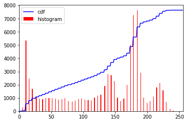

```python
hist, bins = np.histogram(copy.flatten(),256, [0,256])

cdf = hist.cumsum()
cdf_normalized = cdf * hist.max()/cdf.max()

plt.plot(cdf_normalized, color = 'b')
plt.hist(copy.flatten() ,256, [0, 256], color = 'r')
plt.xlim([0, 256])
plt.legend(('cdf','histogram'), loc = 'upper left')
plt.show()
```

[figure not shown]

```python
plt.imshow(copy, cmap="Greys_r", vmin=0, vmax=255);
```

## Atividade 2

Leia com a OpenCV a figura abaixo:

[figure not shown]

Separe os canais R e B das imagens e analise seus histogramas.

1. A partir dos canais R e B e da análise do histograma é possível identificar a caixa vermelha e a bateria azul?
2. Crie uma imagem numpy em que somente os pixels da caixa vermelha estão brancos e faça seu plot aqui

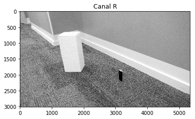

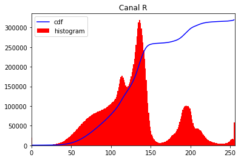

```python
hall = cv2.imread('hall_box_battery1.jpg')
hall_rgb = cv2.cvtColor(hall, cv2.COLOR_BGR2RGB)

vermelho = hall_rgb[:, :, 0]
azul = hall_rgb[:, :, 2]

plt.imshow(vermelho, cmap="Greys_r")
plt.title('Canal R')
plt.show()

hist, bins = np.histogram(vermelho.flatten(),256, [0,256])

cdf = hist.cumsum()
cdf_normalized = cdf * hist.max()/cdf.max()

plt.plot(cdf_normalized, color = 'b')
plt.hist(vermelho.flatten() ,256, [0, 256], color = 'r')
plt.xlim([0, 256])
plt.legend(('cdf','histogram'), loc = 'upper left')
plt.title('Canal R')
plt.show()
```

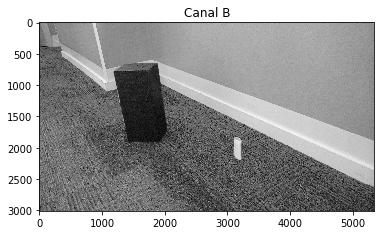

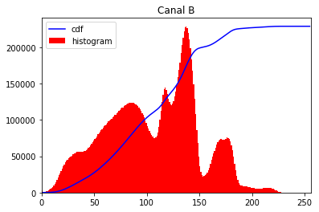

```python
plt.imshow(azul, cmap="Greys_r")
plt.title('Canal B')
plt.show()

hist, bins = np.histogram(azul.flatten(),256, [0,256])

cdf = hist.cumsum()
cdf_normalized = cdf * hist.max()/cdf.max()

plt.plot(cdf_normalized, color = 'b')
plt.hist(azul.flatten(), 256, [0, 256], color = 'r')
plt.xlim([0, 256])
plt.legend(('cdf','histogram'), loc = 'upper left')
plt.title('Canal B')
plt.show()
```

Como pode ser observado nos histogramas acima, não é viável identificar qualquer objeto, seja a bateria azul e ou caixa vermelha. Isso por causa das demais cores presentes na imagem, por exemplo, uma parte branca da parede que também é composta por pixels vermelhos e azuis.

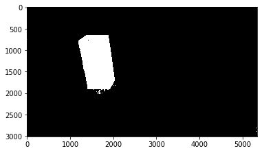

```python
hsv = cv2.cvtColor(hall, cv2.COLOR_BGR2HSV)

light_red = np.array([0, 50, 50])
dark_red = np.array([8, 255, 255])

mask = cv2.inRange(hsv, light_red, dark_red)

plt.imshow(mask, cmap="gray")
plt.show()
```

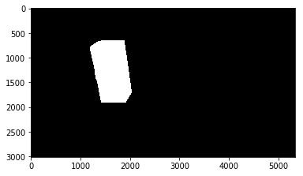

```python
hall_gray = cv2.cvtColor(hall, cv2.COLOR_BGR2GRAY)

copy2 = hall_gray.copy()

for i in range(copy2.shape[0]):
    for j in range(copy2.shape[1]):
        if int(hall_rgb[i, j, 0]) - int(hall_rgb[i, j, 1]) > 80 and int(hall_rgb[i, j, 0]) - int(hall_rgb[i, j, 2]) > 80:
            copy2[i][j] = 255
        else:
            copy2[i][j] = 0

plt.imshow(copy2, cmap='gray');
plt.show()
```

# Atividade 3

Crie uma cópia da versão Grayscale figura acima, em que cada pixel recebe a subtração entre o pixel que vem depois e o que vem antes dele. Apresente a imagem resultado.

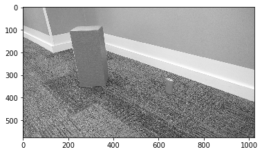

```python
hall3 = cv2.imread('hall_box_battery_atividade3.png')
hall3_gray = cv2.cvtColor(hall3, cv2.COLOR_BGR2GRAY)
plt.imshow(hall3_gray, cmap='Greys_r', vmin=0, vmax=255)
```

[output not shown]

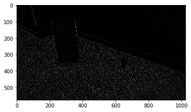

```python
copia = hall3_gray.copy()

for i in range(hall3_gray.shape[0]):
    for j in range(1, hall3_gray.shape[1] - 1):
        a = int(hall3_gray[i][j+1]) - int(hall3_gray[i][j-1])

        if a >= 0 and a <= 255:
            copia[i][j] = a
        else:
            if a < 0:
                copia[i][j] = 0
            else:
                copia[i][j] = 255

plt.imshow(copia, cmap="Greys_r")
cv2.imwrite('copia.png', copia)
```